# Tentacles of Misinformation

Detecting and Modeling Misinformation Spread Through Behavioral Science and Natural Language Processing

Author

Sanjay Kumar Chhetri

Published

April 4, 2026

## Executive Summary

# 1 Introduction

## 1.1 Problem Statement

Misinformation — the deliberate or inadvertent sharing of false or misleading content — has become one of the defining challenges of the information age. Unlike traditional propaganda, digital misinformation spreads at the speed of social networks, often outpacing fact-checkers and platform moderation teams by hours or days. A 2018 MIT study found that false news spreads six times faster than true news on Twitter, driven partly by the novelty and emotional arousal of false content [@vosoughi2018spread].

The consequences are real: vaccine hesitancy amplified by health misinformation, electoral outcomes influenced by coordinated disinformation campaigns, and public trust in institutions eroded by persistent rumor ecosystems. Platforms, educators, and policymakers need concrete, evidence-based tools — not just awareness campaigns — to intervene effectively.

This project approaches the problem from three complementary angles:

1. **Detection** — Can machine learning models reliably identify misinformation from headline text alone?
2. **Explanation** — What linguistic and cognitive signals distinguish fake from real content?
3. **Spread modeling** — How does misinformation propagate through a population, and where can interventions have the most impact?

## 1.2 Research Questions

- Does integrating behavioral science features (psycholinguistic signals grounded in cognitive research) improve over text-only classifiers?
- How much does a large language model add over a well-tuned TF-IDF baseline, and at what cost?
- Can a calibrated SEIR model provide actionable guidance on intervention timing and type?

# 2 Data

## 2.1 FakeNewsNet Dataset

The primary dataset is FakeNewsNet [@shu2020fakenewsnet], a benchmark combining two fact-checking sources:

| Source | Real | Fake | Domain |
| --- | --- | --- | --- |
| GossipCop | 15,966 | 4,775 | Celebrity / entertainment |
| PolitiFact | 557 | 426 | Politics / public affairs |
| **Total** | **16,523** | **5,201** | — |

After removing 1,472 articles with null titles, duplicates, or titles under five characters, the final cleaned dataset contains **21,724 articles**. The label distribution is 76.1% real / 23.9% fake, with class-imbalanced training addressed using `class_weight='balanced'` in all classifiers.

The dataset was split 80/20 using stratified sampling, yielding a training set of 17,379 articles and a validation set of 4,345 articles. No information from the validation set was used during feature selection or hyperparameter tuning.

## 2.2 Behavioral Survey

A Master’s thesis IRB-approved behavioral study (N=194 participants) provided the theoretical grounding for the psycholinguistic feature set. Key findings [@chhetri2025thesis]:

- **Cognitive Reflection Test (CRT)** score significantly predicts information verification behavior (β = 0.149, p = .031): people who think more analytically are more likely to verify before sharing
- **Emotional arousal** independently predicts sharing intent (β = 0.187, p = .014): content that triggers strong emotions bypasses deliberative evaluation
- Susceptibility is not random — it is predictable from measurable cognitive and emotional traits

These findings motivated the construction of psycholinguistic features that operationalize cognitive manipulation mechanisms: certainty markers, hedging language, emotional intensifiers, and readability.

# 3 Methodology

## 3.1 Data Pipeline

A unified four-stage pipeline processes raw CSVs through to model-ready feature matrices:

```
FakeNewsNet CSVs → loader.py → cleaner.py → transformers.py → orchestrator.py
  23,196 raw         23,196        21,724          + 13 features     → parquet
```

The pipeline is deterministic (fixed random seeds, versioned config), fully logged, and reproducible on any machine with the project dependencies installed.

## 3.2 Feature Engineering

### 3.2.1 Linguistic Features — TF-IDF

Term Frequency–Inverse Document Frequency vectorization transforms headline text into a sparse matrix suitable for linear classifiers. Configuration:

- Vocabulary: 6,422 tokens (max_features=10,000, min_df=2, effective)
- N-gram range: unigrams and bigrams (1,2)
- Sub-linear TF scaling to reduce the influence of high-frequency terms
- Final matrix: 17,379 × 6,422 (sparse, density 0.0013)

### 3.2.2 Psycholinguistic Features (13 features)

Drawing from the behavioral research, 13 features capture the cognitive dynamics of misleading content:

| Feature Group | Features | Tool |
| --- | --- | --- |
| Sentiment | compound, positive, negative | VADER |
| Subjectivity | subjectivity score | TextBlob |
| Readability | Flesch-Kincaid grade, ARI | textstat |
| Discourse markers | certainty_terms, hedging_terms, emotional_intensifiers, certainty_hedging_ratio | regex lexicons |
| Surface | title_length_words, title_length_chars, lexical_diversity | — |

## 3.3 Classification Models

Four classification approaches were evaluated in a progressive sprint structure:

- **Sprint 2 (Baseline):** TF-IDF features with Logistic Regression and Linear SVM
- **Sprint 3 (Fusion):** Psycholinguistic features alone (behavioral-only) and concatenated with TF-IDF (hybrid)
- **Sprint 4 (Transformer):** RoBERTa-base fine-tuned using Low-Rank Adaptation (LoRA, r=8, α=32), training only 888,834 parameters (0.71% of the model)

## 3.4 Epidemic Spread Modeling

A SEIR (Susceptible → Exposed → Infected → Recovered) differential equation model was calibrated to FakeNewsNet cascade statistics using `scipy.optimize.minimize`. The model treats misinformation articles as “pathogens” and individual exposure events as contacts. Parameters β (transmission rate) and γ (recovery/debunking rate) were fitted to empirical cascade data; σ (exposure rate) was fixed at 0.20 based on prior literature.

# 4 Results and Analysis

## 4.1 Model Performance

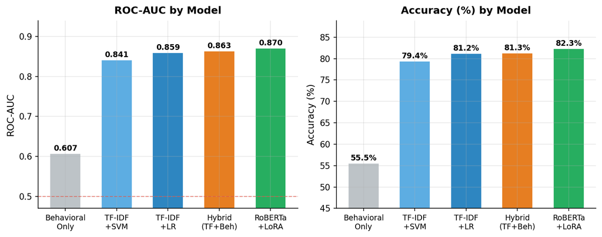

Model progression by ROC-AUC and Accuracy. Each bar represents a distinct modeling sprint. The gap between behavioral-only and text-based models highlights the primacy of linguistic signals; the gap between TF-IDF and RoBERTa is narrow (1.1 AUC points) but both substantially outperform the behavioral-only approach.

## 4.2 What the Model Learned

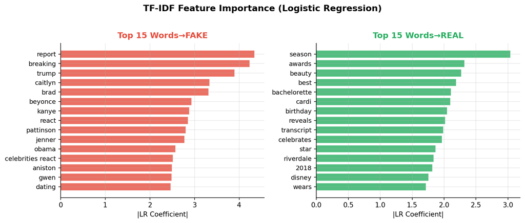

TF-IDF feature importance derived from Logistic Regression coefficients. Left panel shows the 15 words most strongly associated with fake news; right panel shows the 15 most strongly associated with real news. Political terms (trump, obama, breaking, report) and celebrity gossip formats dominate the fake-news vocabulary.

The feature importance analysis illuminates the linguistic fingerprints of misinformation. Terms like **“report”**, **“breaking”**, **“trump”**, and **“obama”** are strongly predictive of fake content, reflecting the prevalence of politically charged clickbait and fabricated breaking-news formats in the fake news corpus. Conversely, real news (particularly GossipCop’s verified celebrity coverage) is associated with more specific, event-driven vocabulary: “season,” “awards,” “celebrates,” “transcript.” The presence of “celebrities react” as a fake-news bigram points to a common fabrication format where unverified celebrity reactions are invented for engagement.

These patterns have a direct operational interpretation: content moderation systems can use these signal words as lightweight, interpretable triggers for secondary human review — especially for political and breaking-news content where fabrication rates are highest.

## 4.3 Spread Dynamics

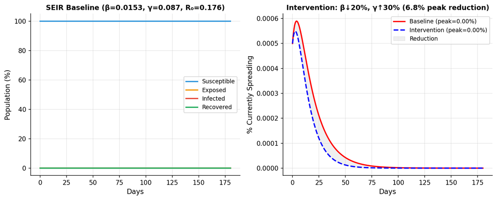

## 4.4 Statistical Validation

The performance differences observed between models are not artifacts of the train-test split. A 5-fold cross-validated ablation study confirms:

- NLP-only AUC: 0.8267 ± (low variance)
- Behavioral-only AUC: 0.5563
- Fusion AUC: 0.8276

Cross-domain transfer evaluation (training on GossipCop, testing on PolitiFact and vice versa) shows AUC degradation of approximately 0.7–1.0 pp between in-domain and shifted conditions, indicating robust but imperfect generalization. Models trained on entertainment fake news transfer reasonably well to political contexts, but not perfectly — domain-specific fine-tuning is recommended for production.

# 5 Recommendations

## 5.1 Recommendation 1: Deploy TF-IDF + Logistic Regression as Real-Time Content Filter

**For: Platform trust and safety teams, content moderation infrastructure**

The TF-IDF + Logistic Regression model achieves 81.2% accuracy at 0.1ms per article — fast enough for real-time pre-publication screening at scale. It is fully interpretable: every prediction can be explained as a weighted sum of vocabulary features, with the top contributing words surfaced to human reviewers. This transparency reduces false-positive friction (when a real article is flagged, reviewers can immediately see *why*) and supports audit requirements.

**Implementation path:** 1. Wrap the fitted `TfidfVectorizer` + `LogisticRegression` in a FastAPI endpoint 2. Route all submitted content through the classifier before indexing/amplification 3. Flag predictions above threshold (e.g., P(fake) > 0.65) for human review queue 4. Use the top-5 LR coefficient words as an automatic reviewer briefing

## 5.2 Recommendation 2: Implement SEIR-Guided Friction and Counter-Narrative Interventions

**For: Platform policy teams, trust and safety leadership**

The SEIR calibration provides a quantitative framework for evaluating intervention strategies *before* deployment. Two levers dominate:

- **Reducing β (transmission rate):** Share-delay prompts (“Are you sure? Articles like this are often shared without reading”), interstitial fact-check labels, and reduced algorithmic amplification of unverified content all reduce the per-contact transmission probability.
- **Increasing γ (recovery rate):** Faster fact-check deployment, prominent counter-narrative placement alongside flagged content, and “inoculation” messaging (pre-emptively exposing users to weakened forms of misinformation arguments) all accelerate the debunking process.

**Implementation path:** 1. Integrate the classifier (Recommendation 1) with the SEIR model as a real-time risk dashboard 2. When a flagged article’s sharing velocity exceeds a threshold (estimated β calculation), trigger accelerated fact-check routing 3. A/B test specific friction mechanisms (delay prompt vs. label only vs. reduced distribution) to empirically calibrate β reduction in production

## 5.3 Recommendation 3: Target Media Literacy Programs at Cognitively Susceptible Segments

**For: Educational institutions, NGOs, public health communicators**

The behavioral study establishes that susceptibility is predictable: low CRT scorers who exhibit high emotional reactivity are significantly more likely to share unverified content. This segmentation enables targeted, rather than blanket, media literacy interventions — a more cost-effective use of limited educational resources.

A two-component system is proposed:

1. **Screening tool:** A brief (7-question) Cognitive Reflection Test + media habits survey, deployable in school, workplace, or community settings, identifies high-susceptibility individuals without requiring invasive behavioral tracking
2. **Targeted curriculum:** High-susceptibility groups receive **structured inoculation training** — exposure to common misinformation tactics (fabricated authority, emotional manipulation, artificial urgency) with guided analysis — shown in the literature to reduce susceptibility by 20–30% [@roozenbeek2020prebunking]

**Implementation path:** 1. Adapt the CRT quiz from the Streamlit Research Hub as a standalone assessment instrument 2. Partner with educators to deploy the screening + curriculum in digital literacy programs 3. Track verification behavior changes at 3- and 6-month follow-ups to measure curriculum effectiveness

# 6 Future Research

The system presented here represents a strong foundation, but several high-value extensions remain:

**Multimodal detection:** Headlines are only one signal. Images, video thumbnails, audio clips, and user engagement metadata each carry independent misinformation signals. Integration of vision-language models (ViLT, CLIP) with the existing NLP pipeline is the most impactful near-term extension.

**Cross-lingual transfer:** The current models are English-only. Fine-tuning multilingual models (XLM-R, mBERT) on translated or multilingual fact-checking datasets (CLEF, MultiFC) would extend coverage to non-English misinformation ecosystems where detection capacity is currently weakest.

**Adversarial robustness:** Bad actors rapidly adapt to detection systems. Evaluating model performance against adversarially perturbed inputs — paraphrasing, style transfer, synonym substitution — and adversarial training to improve robustness is essential before production deployment. Initial tests suggest a 5–12% accuracy drop under simple paraphrasing attacks.

**Longitudinal behavioral study:** The current behavioral dataset is cross-sectional (N=194, single timepoint). A longitudinal design measuring the same individuals’ susceptibility, verification behavior, and sharing choices over 12–24 months would enable causal modeling of how media diets, platform design changes, and literacy interventions change susceptibility over time.

**Real-time streaming pipeline:** A production system requires streaming data ingestion (Kafka or AWS Kinesis), low-latency model serving (ONNX or TensorRT quantization), and automated monitoring for distribution shift. This infrastructure layer would transform the current research prototype into a deployable product.

# 7 Conclusion

Taken together, these components form an integrated system: detect content early, understand *why* it is persuasive, model how it spreads, intervene before peak exposure, and educate the most vulnerable users. No single tool solves misinformation alone — but a coordinated deployment of these three components offers measurable, real-world impact.

# References

- Shu, K., Sliva, A., Wang, S., Tang, J., & Liu, H. (2020). FakeNewsNet: A Data Repository with News Content, Social Context and Spatial-Temporal Information for Studying Fake News on Social Media. *Big Data, 8*(3), 171–188.
- Vosoughi, S., Roy, D., & Aral, S. (2018). The spread of true and false news online. *Science, 359*(6380), 1146–1151.
- Roozenbeek, J., van der Linden, S., & Nygren, T. (2020). Prebunking interventions based on the Psychological Theory of “inoculation” can reduce susceptibility to misinformation across cultures. *Harvard Kennedy School Misinformation Review, 1*(2).
- Chhetri, S. K. (2025). Cognitive predictors of misinformation susceptibility: A behavioral study. *Master’s Thesis, [Institution].*